# *Лабораторна робота № 3*. Основи вибіркового методу

Sydorenko Andii

2024-12-08

**Мета:** *засвоїти основи статистичного оцінювання характеристик випадкової величини на основі вибіркового підходу засобами мови програмування R; набути навичок роботи у середовищі RStudio із застосуванням концепції “грамотного програмування” із застосуванням пакету R Markdown*. *Хід роботи* |

Таблиця 1 – **Теоретичні та емпіричні (вибіркові) числові характеристики випадкової величини**

| Назва числової характеристики | теоретичне значення | Вибіркове значення, $n=100$ | Вибіркове значення, $n=1000$ |
| --- | --- | --- | --- |
| $a$ | $a$ | $\tilde a$ | $\tilde a$ |
| $\sigma$ | $\sigma$ | $\tilde{\sigma}$ | ${\tilde{\sigma}}$ |
| Математичне сподівання | $m(x)$ | $\tilde{m}(x)$ | $\tilde{m}(x)$ |
| Дисперсія | $D(x)$ | $\tilde{D}(x)$ | $\tilde{D}(x)$ |
| Виправлена дисперсія |  | $\tilde{\tilde{D}}(x)$ | $\tilde{\tilde{D}}(x)$ |
| СКВ | $\sigma(x)$ | $\tilde{\sigma}(x)$ | $\tilde{\sigma}(x)$ |
| Виправлене СКВ |  | $\tilde{\tilde\sigma}(x)$ | $\tilde{\tilde\sigma}(x)$ |
| Центральний момент $3$-го порядку | $\mu_3$ | $\tilde{\mu}_3$ | $\tilde{\mu}_3$ |
| Центральний момент $4$-го порядку | $\mu_4$ | $\tilde{\mu}_4$ | $\tilde{\mu}_4$ |
| Асимерія | $A_s$ | $\tilde{A}_s$ | $\tilde{A}_s$ |
| Ексцес | $E_k$ | $\tilde{E}_k$ | $\tilde{E}_k$ |

Генеруємо вибірку з нормального розподілу з параметрами $a=$ 0, $\sigma=$ 1 об’єму $n=$ 100:

```r
set.seed(0)
X <- rnorm(n, a, s)
X3 <- rexp(n3, rate = 3)
cat("\n", "Параметри вибірки X:", "\n", "a = ", a, "\n" , "s = ", s, "\n" , "n = ", n, "\n")
```

```
 Параметри вибірки X:
 a =  0
 s =  1
 n =  100
```

```r
cat("Перші елементи вибірки X:", head(X))
```

```
Перші елементи вибірки X: 1.262954 -0.3262334 1.329799 1.272429 0.4146414 -1.53995
```

```r
cat("Останні елементи вибірки X:", tail(X))
```

```
Останні елементи вибірки X: 0.596259 0.1197176 -0.2821739 1.455988 0.2290196 0.9965439
```

```r
cat("\n", "Параметри вибірки X3:", "\n", "a = ", a, "\n" , "s = ", s, "\n" , "n =  ", n3, "\n")
```

```
 Параметри вибірки X3:
 a =  0
 s =  1
 n =   1000
```

```r
cat("Перші елементи вибірки X3:", head(X3))
```

```
Перші елементи вибірки X3: 0.1885676 0.2543933 0.5242389 0.6118803 0.01238409 0.04185529
```

```r
cat("Останні елементи вибірки X3:", tail(X3))
```

```
Останні елементи вибірки X3: 0.009611221 0.02818981 0.01701398 0.01510813 0.4712041 0.272083
```

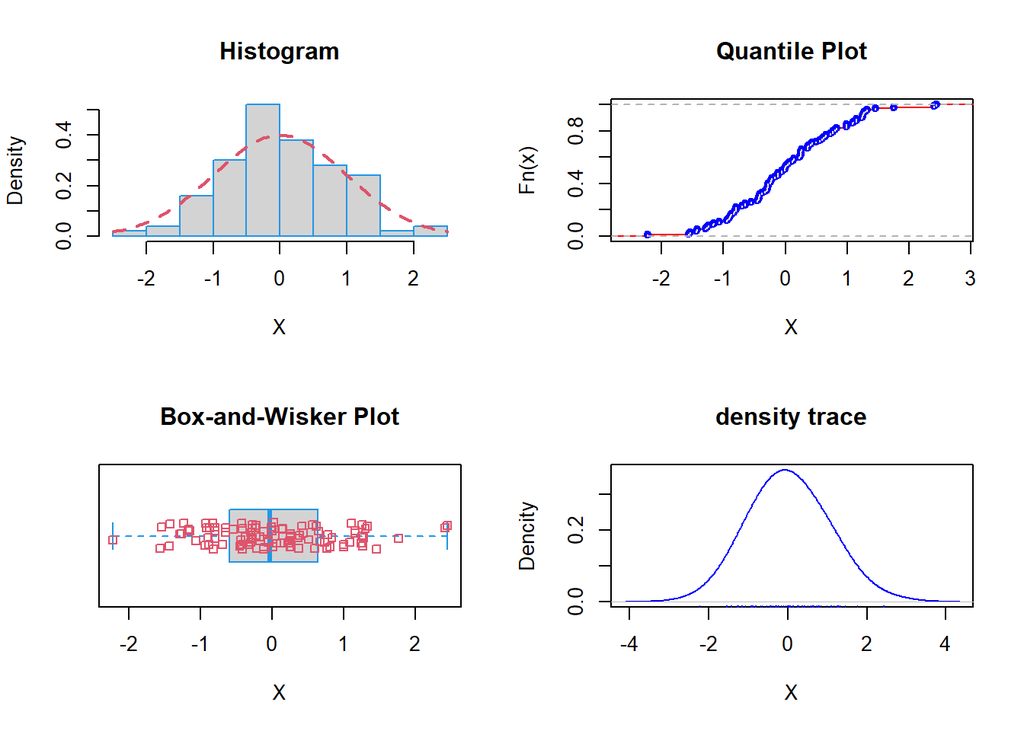

```r
op <- par(mfrow = c(2,2))
Fn <- ecdf(table(cut(X, nclass.Sturges(X))))
Fn <- ecdf(X)

hist(X,
freq = FALSE,
col = "Lightgray",
main="Histogram",
border=4)
curve(dnorm(x, a, s),
col = 2,
lty = 2,
lwd = 2,
add = TRUE)

plot(Fn,
main = "Quantile Plot",
verticals = TRUE,
col.points = "blue",
col.hor = "red",
col.vert = "bisque",
xlab = "X",
ylab = "Fn(x)")

boxplot(X,
main = "Box-and-Wisker Plot",
col = "Lightgray",
border = 4,
xlab = "X",
ylab = "",
horizontal = TRUE)

stripchart(X, method = "jitter", col = 2, add = TRUE)

plot(density(X, adjust=2),
main = "density trace",
xlab = "X",
ylab = "Dencity",
col="blue")
rug(X, ticksize = 0.01, col="blue")
```

Результати моделювання зводимо у таблицю

```r
library(knitr)
results <- data.frame(
  Характеристика = c("Математичне сподівання", "Дисперсія", "Виправлена дисперсія",
                     "СКВ", "Виправлене СКВ", "Центральний момент 3-го порядку",
                     "Центральний момент 4-го порядку", "Асимметрія", "Ексцес"),
  Вибірка_X = c(mean(X), var(X), var(X) * n / (n - 1), sd(X), sqrt(var(X) * n / (n - 1)),
                mu_3, mu_4, A_s, E_k),
  Вибірка_X3 = c(mean(X3), var(X3), var(X3) * n3 / (n3 - 1), sd(X3),
                 sqrt(var(X3) * n3 / (n3 - 1)), mu_3_X3, mu_4_X3, A_s_X3, E_k_X3)
)

kable(results, caption = "Результати обчислень")
```

Результати обчислень

| Характеристика | Вибірка_X | Вибірка_X3 |
| --- | --- | --- |
| Математичне сподівання | 0.0226684 | 0.3367576 |
| Дисперсія | 0.7790714 | 0.1058844 |
| Виправлена дисперсія | 0.7869408 | 0.1059904 |
| СКВ | 0.8826502 | 0.3253989 |
| Виправлене СКВ | 0.8870968 | 0.3255617 |
| Центральний момент 3-го порядку | 0.1540149 | 0.0638897 |
| Центральний момент 4-го порядку | 1.7608217 | 0.0867660 |
| Асимметрія | 0.2239736 | 1.8543132 |
| Ексцес | -0.0989121 | 4.7390134 |

**1. Що таке вибірка?**

Вибірка — це підмножина даних, яка вибирається з більшої сукупності, що називається генеральною сукупністю. Вибірка використовується для проведення досліджень і аналізу, коли неможливо або недоцільно працювати з усією генеральною сукупністю.

**2. Як можна оцінити вибіркове математичне сподівання?**

Вибіркове математичне сподівання — це середнє значення всіх елементів у вибірці. Воно є оцінкою математичного сподівання генеральної сукупності. Це те, що майже середнє арифметичне і обчислюється за формулою:

$$\overline{X} = \frac{1}{n} \sum_{i=1}^{n} X_i$$

де:

- $\overline{X}$ — вибіркове математичне сподівання,
- $n$ — кількість елементів у вибірці,
- $X_i$ — значення кожного окремого елемента вибірки.

**3. Які існують міри розcіювання?** Основні міри розсіювання: Існує декілька основних мір розсіювання, які використовуються для оцінки варіативності або розподілу даних у вибірці чи генеральній сукупності. Ось найпоширеніші з них:

1. **Розмах (Range)**
2. **Дисперсія (Variance)**
3. **Середньоквадратичне відхилення**
4. **Квартильне відхилення**
5. **Середнє абсолютне відхилення**

Кожна з цих мір має свої особливості і використовується в залежності від специфіки даних і цілей аналізу.

**4. Які міри форми розподілу вам відомі? Що вони характеризують? Як їх оцінити на практиці?**

Міри форми розподілу використовуються для аналізу і опису особливостей форми розподілу даних. Основні міри включають:

1. **Асиметрія:**
   - Характеризує асиметричність розподілу. Вказує на те, як сильно розподіл нахилений вліво або вправо відносно середнього значення.
   - Формула для вибіркової асиметрії:
     $$A_s = \frac{1}{n} \sum_{i=1}^{n} \left(\frac{X_i -
     \overline{X}}{s}\right)^3$$
   - Практичне значення:
     - Якщо асиметрія > 0, розподіл нахилений вправо (довший хвіст справа).
     - Якщо асиметрія < 0, розподіл нахилений вліво (довший хвіст зліва).
     - Якщо асиметрія ≈ 0, розподіл симетричний.
2. **Ексцес:**
   - Характеризує “высоту” та “гостроту” розподілу в порівнянні з нормальним розподілом.
   - Формула для вибіркового ексцесу:
     $$E_k= \frac{1}{n} \sum_{i=1}^{n} \left(\frac{X_i -
     \overline{X}}{s}\right)^4 - 3$$
   - Практичне значення:
     - Ексцес > 0: розподіл має гострішу вершину (висококуртний, або лептокуртичний).
     - Ексцес < 0: розподіл має більш плоску вершину (платикуртичний).
     - Ексцес = 0: розподіл має нормальну “висоту” (месокуртичний).